# Probability Review

P. Aronow & B. Miller (2019) *Foundations of Agnostic Statistics*, Cambridge University Press

- “Agnostic statistics” considers what can be learned about the world without assuming that there exists a simple generative model that can be known to be true.
- Credible research is incompatible with *incredible* modeling assumptions.

## Introduction

**Frequentist probability**. The probability of an event describes the proportion of times that event can be expected to occur among many realizations of a random generative process. It’s all about long-term frequencies.

The mathematical construct of randomness is a *modeling assumption*, not necessarily a fundamental feature of reality. It allows us to model the outcomes of a process, stripping away all the complexities that would otherwise allow us to predict any outcome *with certainty*.

There are three formal components that together fully describe a random generative process: $\Omega, S, P$.

The **sample space** ($\Omega$) or the set of all possible outcomes of a random generative process. Individual outcomes (or sets of outcomes) are usually denoted as $w \in \Omega$, and they can take many forms.

For example:

- A single roll of a six-sided die.

$$\Omega = \{1, 2, 3, 4, 5, 6\}$$

- A single roll of two six-sided dice.

$$\Omega = \{(x, y) \in \mathbb Z^2 : 1 \leq x \leq 6,\ 1 \leq y \leq 6 \}$$

- A coin flip.

$$\Omega = \{H, T\}$$

An *event* is a well-defined subset of $\Omega$, usually denoted by capital Roman letters (e.g. $A \subseteq \Omega$).

For example:

- Rolling an even number with a six-sided die.

$$A = \{2, 4, 6\}$$

A set of subsets of $\Omega$ is an **event space** ($S$) if it satisfies the following properties:

- non-empty

$$S \neq \varnothing$$

- closed under complements

$$A \in S \to A^C \in S$$

- closed under countable unions

$$A_1, A_2, ... \in S \to A_1 \cup A_2 \cup ... \in S$$

*Each event in an event space will have an associated probability of occurring*, and these properties ensure that certain types of events will always have well-defined probabilities.

A **probability measure** ($P$) is a function $f: S \to [0, 1]$ that assigns a probability to every event in the event space.

To ensure that this function $P$ assigns probabilities to events in a manner that is coherent and in accord with basic intuitions about probabilities, we follow the *Kolmogorov probability axioms*.

**Kolmogorov probability axioms**

$(\Omega, S, P)$ form a *probability space* when the following conditions hold:

1. Non-negativity, for any $A \in S$

$$0 \leq P(A) \leq 1$$

2. Unitary (or normalization)

$$P(\Omega) = 1$$

3. Countable additivity, if $A_1, A_2, ... \in S$ are *pairwise disjoint*, then

$$P(A_1 \cup A_2, \cup ...) = P(A_1) + P(A_2) + ...$$

We can represent any random generative process as a probability space $(\Omega,S,P)$.

Several other fundamental properties of probability follow directly from the Kolmogorov axioms:

Let $A, B \in S$

- **Monotonicity**

$$A \subseteq B \to P(A) \leq P(B)$$

- **Subtraction rule**

$$A \subseteq B \to P(B \setminus A) = P(B) - P(A)$$

- *Some* event in $S$ *must* occur

$$P(\varnothing) = 0$$

- **Complement rule**

$$P(A^C) = 1 - P(A)$$

### Joint and conditional probabilities

The **joint probability** of of $A$ and $B$ (i.e. that both events will ocur in a single draw from $(\Omega, S, P)$) is denoted as $P(A \cap B)$.

For example, the probability of rolling a six-sided die and getting $A = \{\omega \in \Omega: \omega \geq 4\}$ *and* $B = \{\omega \in \Omega: \omega \text{ is even}\}$ is as follows:

$$P(A \cap B) = P(\{4, 5, 6\} \cap \{2, 4, 6\}) = \frac{|\{4, 6\}|}{|\Omega|} = \frac{1}{3}$$

- **Addition rule**

$$P(A \cup B) = P(A) + P(B) - P(A \cap B)$$

The **conditional probability** of $A$ given $B$ is denoted as

$$P(A \mid B) = \frac{P(A \cap B)}{P(B)}$$

- **Product rule**

$$P(A \mid B) P(B) = P(A \cap B)$$

- **Bayes’ rule**

$$P(A \mid B) = \frac{P(B \mid A) P(A)}{P(B)}$$

The **law of total probability** states that if $\{A_1, A_2, A_3, ...\}$ is a **partition** of $\Omega$ and $B \in S$, then

$$P(B) = \sum_i P(B \cap A_i) = \sum_i \underbrace{P(B \mid A_i) P(A_i)}_\text{product rule}$$

In other words, the probability of an event $B$ is effectively a weighted average of the conditional probabilities of that event ($B$).

**Events and conditional probabilities**. When writing $\Pr(A\mid E)$, we do *not* mean that $A \mid E$ is an event and that we’re taking its probability.

$$A \mid E \hspace{0.3cm} \text{is not an event!}$$

- $\Pr(A \mid E)$ is a probability function which assigns probabilities in accordance with the knowledge that $E$ has occurred.
- $\Pr(A)$ is a different probability function which assigns probabilities without regard for whether $E$ has occurred or not.

### Independence

Events $A, B \in S$ are *independent* if $P(A \cap B) = P(A)P(B)$. This also implies the following:

$$A \perp B \iff P(A \mid B) = P(A)$$

That is, when $A$ and $B$ are independent, knowing whether or not $B$ has occurred gives us no information about the probability that $A$ has occurred. This is a very strong assumption, but it lies in the heart of many applications in statistics that work with independent and identically distributed (*i.i.d.*) random variables.

- **Conditional independence**

$$A \perp B \mid E \iff P(A \cap B \mid E) = P(A \mid E) P(B \mid E)$$

This is different from saying that $A$ and $B$ are independent themselves.

In general:

- Two events can be conditionally independent given $E$, but not independent.
- Two events can be independent, but not conditionally independent given $E$.
- Two events can be conditionally independent given $E$, but not independent given $E^C$.

## Random Variables

A **random variable**, $X$, is a function from the sample space, $\Omega$, to some subset of $\mathbb{R}$ with a probability-based rule.

$$X: \Omega \to \mathbb R$$

Recall that each $\omega \in \Omega$ denotes a state of the world. A random variable $X$ will take take on the value $X(\omega)$.

For example, the event $\{X = 1\}$ should be understood the set of of states of the world such that $X(\omega) = 1$.

$$P(\{X = 1\}) = P(\{\omega \in \Omega: X(\omega) = 1\})$$

There are two ways in which to apply functions to random variables:

1. **Function of a random variable**. Use the value of $X(\omega)$ as input into another function $g$, with the result being another random variable.

   $$g \circ X: \Omega \to \mathbb R$$

   For example:

   $$g(X) = \begin{cases} 1 &\text{if } X>0 \\ 0 &\text{otherwise}
   \end{cases}$$
2. **Operator on random variable**. These will summarize the properties of random variables such as *expectations* or *variances*. We use the $[\cdot]$ notation to denote operators.

We use uppercase to denote random variables and lowercase to denote particular realizations (or variables in the regular, algebraic sense).

- A **discrete random variable** can only can take on a finite (or countably infinite) number of different values.
- A **continuous random variable** can take on a continuum of possible values. Loosely speaking, a random variable is continuous if its CDF is continuous.

### PMFs, PDFs, and CDFs

Given a discrete random variable $X$, we can summarize the probability of each outcome $x$ occurring with a **probability mass function** (PMF). A continuous random variable is characterized by its **probability density function** (PDF).

$$\underbrace{f(x) = P(X = x)}_\text{PMF} \hspace{1cm}
\int_a^b \underbrace{f(x)}_\text{PDF}dx = P(a \leq X \leq b)$$

Note that both functions must be non-negative

$$f(x) \geq 0 \hspace{0.5cm} \text{ for all } x \in \mathbb R$$

These functions tell us *most* of what we need to know about the **distribution** of random variables (i.e. the complete collection of probabilities assigned to events defined in terms of $X$).

The **cumulative distribution function** (CDF) tell us *everything* we need to know about the distribution of random variables. More importantly, a CDF is defined the same way for both discrete *and* continuous random.

The CDF of $X$ is defined as

$$F(x) = P(X \leq x) \hspace{0.5cm} \text{ for all } x \in \mathbb R$$

In other words, the CDF returns the probability that an outcome for a random variable will be less than or equal to a given value.

Any CDF $F$ will have the following properties:

- **$F$ is nondecreasing as $x$ increases**

$$x_1 < x_2 \to F(x_1) < F(x_2)$$

- Limits

$$\lim_{x \to +\infty} F(x) = 1 \hspace{0.5cm}
\lim_{x \to -\infty} F(x) = 0$$

- **Complement rule**

$$1-F(x) = P(X > x)$$

- **Continuity from the right**. A CDF is always continuous from the right, even if the random variable is discrete (in which case the CDF is a “step function”).

$$\lim_{x \to a^+} F(x) = F(a)$$

In the case of *continuous random variables*, note that the PDF is contained inside the definition of the CDF.

$$\overbrace{F(a) = P(X \leq a) = \int_{-\infty}^a \underbrace{f(x)}_\text{PDF}dx}^\text{Cumulative Distribution Function}$$

That is a probability **density** is the rate of change in cumulative probability. So where cumulative probability is increasing rapidly, density can easily exceed 1. But if we calculate the area under the density function, it will never exceed 1. In other words, the PDF is a “slope” that is defined according to the Fundamental Theorem of Calculus as follows:

$$\underbrace{f(x) = \frac{dF(u)}{du} \bigg|_{u = x}}_\text{Probability Density Function}$$

**Two additional definitions.**

- **Support**. . The set of values at which the PMF (or PDF) is positive is called its support.

$$\textsf{supp}(X) = \{x \in \mathbb R: f(x) > 0\}$$

- The inverse of a CDF ($Q = F^{-1}$) is called the **quantile function**.

  For example:

$$\underbrace{Q(0.5)}_\text{median} = x \iff P(X \leq x) = 0.5$$

## Relationships

When we say two random variables are equal, we mean that they are *equal as functions*; they assign the same value to every state of the world.

$$X = Y \iff X(\omega) = Y(\omega)\hspace{0.5cm} \forall \omega \in \Omega$$

**Discrete multivariate distributions** are described by their *joint* CDF, PMF, or PDF.

$$\overbrace{F(a, b) = P(X \leq a \cap Y \leq b) = \int_{-\infty}^a \int_{-\infty}^b \underbrace{f(x, y)}_\text{joint PDF}dy dx}^\text{Joint Cumulative Distribution Function}$$

The same as before, integrating over a PDF will give us probability statements such as

$$P(a \leq X \leq b, c \leq Y \leq d) = \int_a^b \int_c^d f(x, y)dydx$$

The same goes for summing over a PMF:

$$P(a \leq X \leq b, c \leq Y \leq d) = \sum_{x = a}^b \sum_{y = c}^d f(x, y)$$

And the “slope” interpretation extends to multiple variables too:

$$\underbrace{f(x, y) = \frac{\partial F(u, v)}{\partial u \partial v} \bigg|_{u = x, v = y}}_\text{Joint Probability Density Function}$$

And for the discrete setting:

$$\underbrace{f(x, y) = P(X = x, Y = y)}_\text{Joint Probability Mass Function}$$

**Marginalization**. We can go from multivariate to univariate distributions with summation (for PMFs) or integration (for PDFs). Both of these follow from the *law of total probability*.

- **Marginal PMF**

$$f_Y(y) = P(Y = y) = \sum_{\textsf{supp}[X]} f_{X, Y}(x, y)$$

- **Marginal PDF**

$$\text{Continuous: }f_Y(y) = \int_{-\infty}^\infty f_{X, Y}(x, y)dx$$

**Conditional Distributions**. The *conditional PMF* of $Y$ given $X$ tells us the probability that a given value of $Y$ will occur, given that a certain value of $X$ occurs. In contrast, the conditional PDF of $Y$ given $X$ is just the PDF of $Y$ given that a certain value of $X$ occurs.

- **Conditional PMF**

$$\begin{align}
f_{Y \mid X}(y \mid x) = P(Y = y \mid X = x) = \frac{f(x, y)}{f(x)} \\\\ \forall y \in \mathbb R \text{ and } \underbrace{\forall x \in \textsf{supp}(X)}_{\text{denominator} \neq 0}
\end{align}$$

- **Conditional PDF**

$$f_{Y \mid X}(y \mid x) = \frac{f(x, y)}{f(x)} \hspace{0.5cm} \forall y \in \mathbb R \text{ and } \forall x \in \textsf{supp}[X]$$

- **Product rule for PMFs and PDFs**

$$f(x \mid y)f(y) = f(x, y)$$

- **Independence of random variables** regardless of whether they are discrete or continuous.

$$X \perp Y \iff f(x, y) = f(x) f(y)$$

$$X \perp Y \iff f(x \mid y) = f(x)$$

### Multivariate notation

A **random vector** of length $K$ is a vector whose components are random variables:

$$\mathbf X (\omega) = \pmatrix{X_{[1]} (\omega), & \dots, & X_{[K]} (\omega)}$$

Here, we use bracketed subscripts to denote distinct random variables because later on we use plain subscripts to denote multiple independent realizations of a single random variable.

The use of boldface will make us be able to express complicated expressions in a simple manner.

For example:

$$\underbrace{F(\mathbf x)}_\text{CDF} = P(\mathbf X \leq \mathbf x) = P(X_{[1]} \leq x_{[1]}, X_{[2]} \leq x_{[2]}, \dots, X_{[K]} \leq x_{[K]})$$

And if we have a continuous random vector, we have the following expression:

$$F(\mathbf x) = \int_{-\infty}^{x_{[1]}} \int_{-\infty}^{x_{[2]}} \dots \int_{-\infty}^{x_{[K]}} = f(u_{[1]}, u_{[2]}, \dots, u_{[K]})du_{[K]} \dots du_{[2]}du_{[1]}$$

## Summarizing distributions

### Expectation

The expected value (also known as the *expectation* or *mean*) is the most common measure of the “center” of a probability distribution.

- Discrete random variables

$$E[X] = \sum_{\textsf{supp}(x)} x f(x)$$

- Continuous random variables

$$E[X] = \int_{-\infty}^\infty x f(x)dx$$

- **Properties of expected values**

$$\begin{align}
&E[c] = c &\text{ for all } c \in \mathbb R \\\\
&E[cX] = c\ E[X] &\text{ for all } c \in \mathbb R
\end{align}$$

- Expectation of a Bernoulli random variable

$$E[X] = P(X = 1) = p$$

**Expectation of a function of a random variable** (also known as *LOTUS*). This comes up in many applications (e.g. finding the *variance* of a random variable), but the result is far from obvious (see here).

- Continuous case

$$E[g(X)] = \int_{-\infty}^\infty g(x) f_X(x) dx$$

- Discrete case

$$E[g(X)] = \sum_{\textsf{supp}(x)} g(x) f_X(x)$$

- **Linearity of expectations**

$$E[aX + bY + c] = aE[X] + bE[Y] + c$$

Note that this property follows from considering the expectation of a function of a bivariate joint distribution.

$$\underbrace{g(X, Y) = aX + bY + c}_\text{function of a bivariate joint distribution}$$

Apply *LOTUS* and *marginalization*:

$$\begin{align}
E[g(X, Y)] &= \sum_x \sum_y g(X, Y) f_{XY}(x,y) \\\\ &=
\sum_x \sum_y (ax + by + c) f_{XY}(x,y) \\\\ &=
a\sum_x \sum_y x f_{XY}(x,y) + b\sum_x \sum_y y f_{XY}(x,y)+ c\sum_x \sum_y f_{XY}(x,y)
\end{align}$$

### Moments and variances

We can generalize expectations to further characterize the features of a distribution. This is the idea of **raw moments**, among which the expected value is just a special case.

$$\underbrace{\mu_j^\prime = E[X^j]}_{j^{th}\text{ raw moment }}$$

Raw moments provide summary information about a distribution, describing elements of its *shape* and *location*.

- **Central moments**

$$\mu_j = E\left[(X - E[X])^j\right]$$

The sole distinction between raw and central moments lies in whether or not the expected value of $X$ is subtracted before calculations.

- The **variance** (second central moment)

$$V[X] = E\left[(X - E[X])^2\right] = E\left[X^2\right] - E[X]^2$$

The variance measures the expected value of the squared difference between the observed value of $X$ and its mean. Note that the first central moment equals zero.

- **Properties of variances**

$$\begin{align}
&V[X + c] = V[X] &\text{ for all } c \in \mathbb R \\\\
&V[cX] = c^2\ E[X] &\text{ for all } c \in \mathbb R
\end{align}$$

- **Standard deviation**

$$\sigma[X] = \sqrt{V[X]}$$

The standard deviation is often preferable to the variance, since it is on the same scale as the random variable of interest.

Knowing these two quantities ($E[X]$ and $\sigma[X]$) tells *everything* about normal distributions.

- **The normal distribution**

$$X \sim \textsf{normal}(\mu, \sigma)$$

$$E[X] = \mu \hspace{0.5cm} \text{ and } \hspace{0.5cm}
\sigma[X] = \sigma$$

$$f_X(x) = \frac{1}{\sigma \sqrt{2 \pi}} \exp\left(-\frac{1}{2 \sigma^2} (x - \mu)^2\right)$$

Any linear combination of any number of mutually independent normal random variables must itself be normal.

$$X \perp Y \to X + Y \sim \textsf{normal}\left(\mu_X + \mu_Y, \sqrt{\sigma_X^2 + \sigma_Y^2}\right)$$

### Mean Squared Error

MSE is a metric that characterizes how well a random variable $X$ approximates a certain value $c$.

$$MSE = E\left[(X - c)^2\right]$$

Note that the MSE about zero is the same as the *second raw moment*, and the MSE about $E[X]$ is the same as the *second central moment*, which is also the variance.

- **Root Mean Squared Error**

  $$\sqrt{E\left[(X - c)^2\right]}$$

  Note. This is used as a common measure of accuracy in the context of estimation.
- **Decomposition**

$$\begin{align}
E\left[(X - c)^2\right] &= E\left[(X^2 - 2cX + c^2\right] \\\\ &=
E\left[X^2\right] - 2cE[X] + c^2 \\\\ &=
E\left[X^2\right] \underbrace{- E[X]^2 + E[X]^2}_\text{clever trick} - 2cE[X] + c^2 \\\\ &=
\left(E\left[X^2\right] - E[X]^2\right) + \left(E[X]^2 - 2cE[X] + c^2\right) \\\\ &=
V[X] + (E[X]-c)^2
\end{align}$$

**Note.** In the context of estimation, this is also known as the *bias-variance decomposition*.

The MSE is also linked to an alternative definition of the mean: the value $c$ that minimizes the MSE of $X$ is $E[X]$.

$$\underset{c \in \mathbb R}{\arg \min}\ E\left[(X - c)^2\right] = E[X]$$

If we where to choose a different “loss function” besides the MSE, we could come up with different “best” choices for $c$. For example, the *median* is the value $c$ that minimizes the Mean Absolute Error ($|X - c|$).

## Summarizing joint distributions

### Covariance

Covariance measures the extent to which two random variables “move together.”

$$\begin{align}
\text{Cov}[X, Y] &= E\big[(X - E[X])(Y - E[Y])\big] \\\\ &=
E[XY] - E[X]E[Y]
\end{align}$$

- **Variance Rule** (non-linearity of variances)

$$V[X + Y] = V[X] + 2\text{Cov}[X, Y] + V[Y]$$

- **Variance is a special case of Covariance**

$$\text{Cov}[X, X] = V[X]$$

- **Covariance of sums**

$$\text{Cov}[X + W, Y + Z] = \text{Cov}[X, Y] + \text{Cov}[X, Z] + \text{Cov}[W, Y] + \text{Cov}[W, Z]$$

Much like standard deviation rescales variance, correlation rescales covariance to make its interpretation clearer. The **correlation** of two random variables is as follows:

$$\rho[X, Y] = \frac{\text{Cov}[X, Y]}{\sigma[X] \sigma[Y]}$$

The correlation $\rho$ is bounded in $[-1, 1]$, a fact that derives from the *Cauchy-Schwarz inequality*.

**Linear dependence** describes the relationship between two random variables where one can be written as a linear function of the other. And correlation measures the degree of linear dependence between two random variables.

$$\begin{align}
&\rho[X, Y] = 1 \iff Y = a + bX \\\\
&\rho[X, Y] = -1 \iff Y = a - bX \\\\
&\text{where } b > 0 \text{ and } a,b \in \mathbb R
\end{align}$$

If two random variables are *linearly* independent, then $\text{Cov}[X, Y] = 0$. This fact follows from the definition of covariance and the application of LOTUS.

$$\begin{align}
E[XY] &= \int_{-\infty}^\infty \int_{-\infty}^\infty x y f(x, y)dydx \\\\ &=
\int_{-\infty}^\infty \int_{-\infty}^\infty xy f_X(x)f_Y(y)dydx \\\\ &=
\int_{-\infty}^\infty x f_X(x)dx \int_{-\infty}^\infty y f_Y(y) \\\\ &=
E[X]E[Y]
\end{align}$$

That is, *no relationship between two random variables implies no linear relationship them.* However, the opposite is not true: lack of correlation does *not* imply independence.

$$X \perp Y \longrightarrow \text{Cov}[X, Y] = 0$$

### Conditional Expectations

Conditional expectations allow us to describe how the “center” of one random variable’s distribution changes once we condition on the observed value of another random variable.

- Discrete case ($\forall x \in \textsf{supp}[X]$)

$$E[Y \mid X = x] = \sum_y y f_{Y \mid X}(y \mid x)$$

- Continuous case ($\forall x \in \textsf{supp}[X]$)

$$E[Y \mid X = x] = \int_{-\infty}^\infty y f_{Y \mid X}(y \mid x)dy$$

Note that LOTUS can also be applied to conditional expectations of functions of many random variables.

$$E[g(X, Y) \mid X = x] = \int_{-\infty}^\infty g(x, y) f_{Y \mid X}(y \mid x)dy$$

Unlike unconditional expectations, $E[Y \mid X = x]$ is a *family of operators* on the random vector $(X, Y)$ that is indexed by $x$.

A **conditional expectation function** (CEF) is just a conditional expectation takes is sometimes denoted by $G_Y(x)$ to emphasize the fact that it’s a *function* that maps $x$ to $E[Y \mid X = x]$ rather than the value of $E[Y \mid X = x]$ at some particular $x$. This notation also emphasizes the fact that it’s a function of $x$, not a function of the random variable $Y$.

We write $E[X \mid Y]$ to denote $G_Y(X)$ which is a function of the random variable of $X$, and thus it’s also a random variable.

The CEF is closely linked to various topics such as *regression*, *missing data*, and *causal inference*.

- **Law of total expectations** (also known as the law of iterated expectations or Adam’s law).

  $$E[Y] = E\big[E[Y \mid X]\big]$$

  It implies that the unconditional expectation can be represented as a weighted average of conditional expectations, where the weights are proportional to the probability distribution of the variable being conditioned on.

  *Proof*

$$\begin{align}
E[Y] &= \sum_y y f_Y(y) \\\\ &=
\sum_y y \sum_x f_{X, Y}(x, y) \\\\ &=
\sum_x \sum_y y f_{X \mid Y}(y \mid x) f_X(x) \\\\ &=
\underbrace{\sum_x \overbrace{\bigg(\sum_y y f_{Y \mid X} (y \mid x)\bigg)}^{E[Y \mid X = x]} f_X (x)}_{E\big[E[Y \mid X]\big]}
\end{align}$$

- **Law of total variance** (also known as Eve’s law).

  $$V[Y] = \underbrace{E\big[V[Y \mid X]\big]}_\text{within-group variation} + \underbrace{V\big[E[Y \mid X]\big]}_\text{between-group variation}$$

  This theorem allows us to decompose the variability of a random variable $Y$ into the average variability “within” values of $X$ and the variability “across” values of $X$.

  The ordering of the $E$’s and $V$’s spells out $EVVE$, hence the name “Eve’s law”.

  *Proof*.
  1. $E[Y] = E\big[E[Y \mid X]\big] = E[G_Y(X)]$ (Adam’s law)
  2. $E \big[V[Y \mid X]\big] = E\big[E[Y^2 \mid X] - G_Y(X)^2\big] = E\big[Y^2\big] - E\big[G_Y(X)^2\big]$
  3. $V[E[Y \mid X]] = E\big[G_Y(X)^2\big] - E[G_Y(X)]^2 = E\big[G_Y(X)^2\big] - E[Y]^2$

  We add (2) and (3) to get back to the original definition of $V[Y] = E\big[Y^2\big] - E[Y]^2$.

We can also look at Eve’s law from a different perspective:

- “Another way to think about Eve’s law is in terms of *prediction*. If we wanted to predict someone’s height ($Y$) based on their age ($X$) alone, the ideal scenario would be if everyone within an age group had exactly the same height, while different age groups had different heights. Then, given someone’s age, we would be able to predict their height perfectly. In other words, the ideal scenario for prediction is *no* within-group variation in height, since the within-group variation cannot be explained by age differences. For this reason, within-group variation is also called *unexplained variation*, and between-group variation is also called *explained variation*. Eve’s law says that the total variance of $Y$ is the sum of unexplained and explained variation” (Blitzstein & Hwang 2014).

### Best Predictors

Suppose we knew the full joint cumulative distribution function (CDF) of $X$ and $Y$, and then someone gave us a randomly drawn value of $X$. What would be the guess of $Y$ that would have the lowest MSE? The function $g(X)$ that best approximates $Y$ is the CEF.

- $E[Y|X]$, is the best (minimum MSE) predictor of $Y$ given $X$.

This makes the CEF a natural target of inquiry: if the CEF is known, much is known about how $X$ relates to $Y$. But in many cases the CEF can turn out to be an extremely complicated function.

What if we were to restrict ourselves to just *linear functions* of the form $g_Y(x) = a + b X$? We could then define the **best linear predictor** (BLP) of $Y$ given $X$ as the set of values $(a, b)$ that minimizes the MSE.

The BLP is expressed as:

$$(\alpha, \beta) = \underset{a, b \in \mathbb R}{\arg \min}\ E\big[(Y - a + b X)^2\big]$$

Using some calculus, one can show that these values are:

$$\begin{align}
&\alpha = E[Y] - \frac{\text{Cov}[X, Y]}{V[X]} E[X] \\\\
&\beta = \frac{\text{Cov}[X, Y]}{V[X]}
\end{align}$$

**Note.** This expression is identical to the one provided by the method of *ordinary least squares* (OLS), which is designed to estimate population parameters from sample data.

There are two important corollaries that follow from this:

1. The BLP is also the best linear approximation of the CEF.

$$(\alpha, \beta) = \underset{a, b \in \mathbb R}{\arg \min}\ E\bigg[\big(E[Y \mid X] - (a + b X)\big)^2\bigg]$$

2. If the CEF is linear, then the CEF *is* the BLP.

Note that these are some of the implications of **independence** for conditional expectations:

$$\begin{align}
Y \perp X \iff &1.\ E[Y \mid X] = E[Y] \\\\ &2. V[Y \mid X] = V[Y] \\\\ &3. \text{ The BLP of } Y \text{ given } X \text{ is } E[Y]
\end{align}$$

**Plotting the CEF and BLP**

Suppose we have the following random variables and that we are interested in approximating the CEF $G_Y(x)$ with it’s BLP.

$$\begin{align}
&X \sim \text{uniform}(0, 1) \\\\
&W \sim \text{normal}(0, 1) \\\\
&Y = 10X^2 + W
\end{align}$$

By linearity of expectations, can conclude that the CEF is just

$$E[Y \mid X] = 10 X^2$$

And that the BLP (after some algebra) is given by

$$\begin{align}
&\beta = \frac{10 \big(E\big[X^3\big] - E[X]E\big[X^2\big]\big)}{E\big[X^2\big] - E[X]^2} \\\\
&\alpha = E[10X^2 + W] - \beta E[X]
\end{align}$$

The final solution is given by integrating over $X \sim \text{uniform}(0, 1)$:

$$(\alpha, \beta) = \left(-\frac{5}{3}, 10\right)$$

And plotting both functions over $\textsf{supp}[X]$ looks like this:

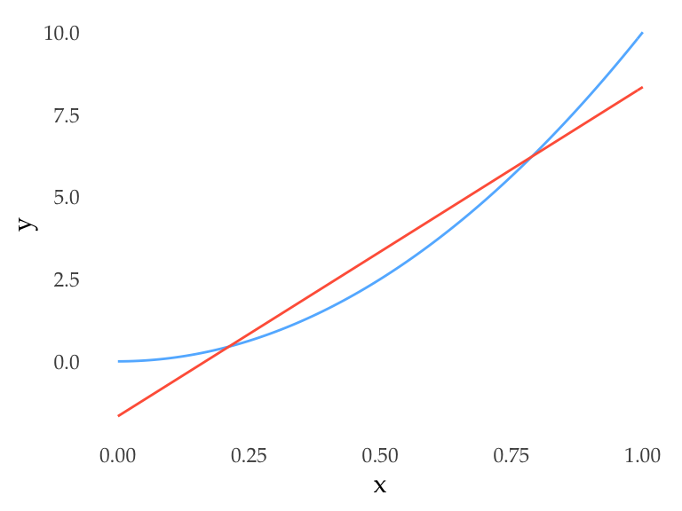

```r
E <- function(m) {
  output <- integrate(
    f = function(x) x^m * fX(x),
    lower = -Inf, upper = Inf
    )$value
}

slope <- function() {
  num <- 10 * (E(3) - E(1) * E(2))
  denom <- E(2) - E(1)^2
  return(num / denom)
}

intercept <- function() {
  10 * E(2) - slope() * E(1)
}

CEF <- function(x) 10*x^2
fX <- function(x) dunif(x, min = 0, max = 1)


tibble(x = 0:1) %>%
  ggplot(aes(x)) +
  stat_function(fun = CEF, color = "steelblue1") +
  stat_function(fun = function(x) intercept() + slope()*x,
                color = "tomato")
```

Here, the BLP (in red) approximates the CEF (in blue) reasonably well over the domain of $X$. While this is not always the case, it is very often the case in the social and health sciences. The BLP is thus a good “first approximation” in a very literal sense, in that it is an approximation with a first-order polynomial.

However, when the CEF is not linear, one must take care in interpreting the BLP as equivalent to the CEF. In particular, this may pose a problem when attempting to make inferences where $X$ has *low probability mass* over some parts of the domain of the CEF. This is because *under nonlinearity, the BLP depends on the distribution of $X$*.

See [**here**](https://acastroaraujo.shinyapps.io/CEF-BLP/) for an interactive demonstration.

### Properties of Residuals

We define deviations (or residuals) with the letter $\epsilon$ and note that they have similar properties when considering with respect to either the CEF or the BLP.

**Properties of deviations**

| CEF | BLP |
| --- | --- |
| $\epsilon = Y - E[Y \mid X]$ | $\epsilon = Y - (\alpha + \beta X)$ |
| $E[\epsilon] = 0$ | $E[\epsilon] = 0$ |
| $E[\epsilon \mid X] = 0$ | $E[\epsilon X] = 0$ (independence) |
| $\text{Cov}[\epsilon, g(X)] = 0$ | $\text{Cov}[\epsilon, X] = 0$ |
| $V[\epsilon \mid X] = V[Y \mid X]$ |  |
| $V[\epsilon] = E\big[V[Y \mid X]\big]$ |  |

## Bounds using inequalities

Taken from Blitzstein & Hwang (2014).

A bound on a probability gives a provable guarantee that the probability is in a certain range. These inequalities will often allow us to narrow down the range of possible values for the exact answer, that is, to determine an upper bound and/or lower bound. These bounds may not provide a good approximation of the exact answer, but at least we know the exact answer is *guaranteed* to be inside the bounds.

- **Markov’s inequality**.

  For any *nonnegative* random variable $X$ and constant $a > 0$:

  $$\Pr(X \geq a) \leq \frac{E[X]}{a}$$

  *Example.* Let $X$ be the income of randomly selected person from a population. If we then say that $a = 2 E[X]$ (or twice the average income in the population), then Markov’s inequality tells us that the probability of selecting someone with more than twice the average income is less than or equal to $0.5$. You can’t have over half the population earning twice the average income!

  Markov’s inequality is a very crude bound because it requires absolutely no assumptions about $X$.

  *Proof*.

  We use an indicator function for the event $Y \geq 1$. Recall that taking the expectation of an indicator function gives us a probability. By definition, the following inequality holds:

  $$\mathbb I(Y \geq 1) \leq Y$$

  To get to Markov’s inequality we replace $Y$ with $\frac{X}{a}$, and take the expectation on both sides:

$$\begin{align}
\Pr\left(\frac{X}{a} \geq 1\right) &\leq \mathbb E\left(\frac{X}{a}\right) \\ \\
\Pr(X \geq a) &\leq \frac{\mathbb E(X)}{a}
\end{align}$$

- **Chebyshev’s concentration inequality**.

  We now say that $X$ has mean $\mu$ and variance $\sigma^2$. Then, for any $a > 0$, we have the following inequality:

  $$\Pr(|X - \mu| \geq a) \leq \frac{\sigma^2}{a^2}$$

  If we substitute $a = b\sigma$, we get an upper bound on the probability that *any* $X$ is more than $b$ standard deviations away from its mean.

  $$\Pr(|X - \mu| \geq b\sigma) \leq \frac{1}{b^2}$$

  *Proof*.

  By Markov’s inequality, we know the following holds:

  $$\Pr(|X - \mu| \geq a) = \Pr\left((X - \mu)^2 \geq a^2\right) \leq \frac{ E\left[(X-\mu)^2\right]}{a^2} = \frac{\sigma^2}{a^2}$$

  **Note.** $X$ is nonnegative and $a > 0$.

## LOTUS

The authors don’t provide a proof for this result, so instead I’ll show here how it plays out. This requires some rudimentary knowledge of **transformations**, which is also omited from the book (see Blitzstein & Hwang 2019).

For simplicity, let’s assume that $Y = g(X)$.

$$\underbrace{f_Y(y) = f_X(x) \left| \frac{d x}{dy} \right|}_\text{Transformation}$$

We can then express $E[Y]$ as follows:

$$\begin{align}
E[Y] &= \int_{-\infty}^\infty y\ f_X(x)\left| \frac{d x}{dy} \right| dy \\\\ &= \int_{-\infty}^\infty g(x)\ f_X(x)dx
\end{align}$$

**Example: The expectation of a standard log-normal distribution**

Suppose we have the following random variables:

- $Y = g(X) = e^X$ and $\frac{dy}{dx} = e^x$
- $X \sim \textsf{normal}(0, 1)$

**Without LOTUS**. Because $f_Y(y)$ is unknown, we need to first figure it out through the use of *transformations*. This step can be immensely complicated in other circumnstances.

$$f_Y(y) = \varphi(x) \left| \frac{d x}{dy} \right| = \varphi(\log y)\frac{1}{y}$$

We then obtain the expectation as follows:

$$\begin{align}
E[Y] &= \int_0^\infty \varphi(\log y) dy \\\\ &=
\int_0^\infty \frac{1}{\sqrt{2 \pi}} \exp\left(- \frac{1}{2} \log^2 y\right) dy \\\\ &= \sqrt{e}
\end{align}$$

**With LOTUS** we don’t have to deal with transformations. Instead, we delve right to it.

$$\begin{align}
E[g(X)] &= \int_{-\infty}^\infty g(x) \varphi(x) dx \\\\ &= \int_{-\infty}^\infty \frac{1}{\sqrt{2 \pi}} \exp\left(x - \frac{x^2}{2}\right) \\\\ &= \sqrt{e}
\end{align}$$

Thus, LOTUS is quicker because we can ignore *transformations*. More importantly, this method is less prone to mistakes because we don’t have to worry about changing the bounds on the integrals!

## Combinations & Permutations

This is *not* from Aronow & Miller.

The probabilities of events can be calculated by counting the number of outcomes in events as a *proportion* of the number of outcomes in the sample space.

**Counting Methods:**

Suppose one event can occur in $m$ ways and that another can occur in $n$ ways.

1. The *sum rule*. As with the union of events, if the two events are disjoint, then there are $m + n$ outcomes or possible ways in which *either one* can happen.
2. The *multiplication rule*. If the two events happen in succession, then there will be $m \times n$ possible outcomes or ways in which they could happen together. In other words, independent possibilities, when considered conjointly, multiply in number.
3. *Permutations*. When the events are *not independent*, we use factorial notation. The number of different permutations of $n$ *distinct* elements in a set is defined using factorial notation $n!$

   When we take a subset $k$ of *distinct* elements, we use:

   $$\underbrace{P(n, k)}_\text{k-permutation} = \frac{n!}{(n - k)!}$$

   Conversely, when a subset $n_1$ of the events in $n$ consists of *indistinct* elements, we use $\frac{n!}{n_1!}$ instead. Furthermore, we can have many subsets of *indistinct* elements:

   $$\frac{n!}{n_1!n_2!...n_r!} \hspace{1cm} \text{s.t} \hspace{0.5cm} n = n_1 + n_2 + ... + n_r$$

   Note that if all possible outcomes are distinct (i.e. each $n_i = 1$) then we are back at $n!$

   Any distinct ordering of a set is called a *permutation* of that set.

   **Example**: If the letters $s$, $s$, $s$, $t$, $t$, $t$, $i$, $i$, $a$, $c$ are arranged in a random order, what is the probability that they will spell the word “statistics”?

   $$\frac{10!}{3!3!2!1!1!} = 50400$$

   Because there’s only one arrangement in which the letters spell “statistics”, the probability is $\frac{1}{50400}$.
4. *Combinations*. A combination is an unordered arrangement of $k$ objects taken from a set of $n$ objects. It is defined by the *binomial coefficient* $\binom{n}{k}$ or the “$n$ choose $k$” operation.

   $$\binom{n}{k} = \frac{n!}{(n-k)! k!}$$

   This turns out to be the number of possible samples of size $k$ drawn *without replacement* from a population of size $n$.

   If we wish to divide a set of $n$ distinct elements into $k$ different subsets of size $n_1 + n_2 + ... + n_k = n$, then the number of given ways in which this can be done is given by the *multinomial coefficient*. This coefficient has already been used in the “statistics” example.

   $$\binom{n}{n_1, ..., n_k} = \frac{n!}{n_1!n_2!...n_k!}$$

**The Sampling Table**

The sampling table gives the number of possible samples of size $k$ out of a population of size $n$, under various assumptions about how the sample is collected.

[output not shown]

[output not shown]

**Exercises**:

As mentioned earlier, the probabilities of events can be calculated by counting the number of outcomes in events as a *proportion* of the number of outcomes in the sample space.

*Example 1.* Draw 2 cards from a deck of 52.

- The probability that both are aces is

  $\frac{\binom{4}{2}}{\binom{52}{2}} = 0.0045$
- The probability that both are spades is

  $\frac{\binom{13}{2}}{\binom{52}{2}} = 0.059$

*Example 2.* Draw five cards from a deck of 52.

- The probability that four of them are aces is

  $\frac{ \binom{4}{4} \binom{48}{1}}{\binom{52}{2}} = 0.000018$

  Notice that the numerator is calculated using the multiplication rule.

## Bayes’ Rule

Taken from Blitzstein & Hwang

**Example: Testing for a rare disease**

A patient is tested for a medical condition that afflicts 1% of the population. Let $D$ be the event that she has the disease and $T$ be the event that she tests positive.

The test is “95% accurate”, which in this case means that $\Pr(T \mid D) = 0.95$ and that $\Pr(T^c \mid D^c) = 0.95$

The quantity $\Pr(T \mid D)$ is known as the “sensitivity” or *true positive rate* of the test, while $\Pr(T^c \mid D^c)$ is known as the “specificity” or *true negative rate*.

Find the conditional probability that the patient has the disease, *given the fact that she tested positive*.

**Solution:**

$$\Pr(D \mid T) = \frac{\Pr(T \mid D) \Pr(D)}{\Pr(T \mid D) \Pr(D) + \Pr(T \mid D^c) \Pr(D^c)} =
\frac{0.95 \times 0.01}{0.95 \times 0.01 + 0.05 \times 0.99} \approx 0.16$$

In this equation, we have that:

$$\Pr(D^c) = 1 - \Pr(D) \hspace{0.5cm} \text{and} \hspace{0.5cm} \Pr(T \mid D^c) = 1 - \Pr(T \mid D)$$

So there is only a 16% chance that she has that disease, given that she tested positive, even though the test seems to be quite reliable! Many people, including doctors, find it surprising that the conditional probability of having the disease given a positive test result is only 16%, even though the test is 95% accurate. The key to understanding this surprisingly high posterior probability is to realize that there are two factors at play: the *evidence* from the test, and our *prior information* about the prevalence of the disease. The conditional probability $\Pr(D \mid T)$ reflects a balance between these two factors, appropriately weighing the rarity of the disease against the rarity of a mistaken test result.

Note that there’s a way to present this same problem in a more intuitive way. Suppose that, instead of being presented with probabilities, you were told the following information:

1. In a population of 100,000 people, 1000 of them have that rare disease.
2. Of those 1000 people, 950 of them will test positive for the disease.
3. Of the remaining 99,000 people (with *no* disease), 4950 of them will test positive for the disease.

What proportion of those who test positive actually have the disease?

$$\frac{950}{4950 + 950} \approx 0.16$$

The second presentation of the problem, using counts rather than probabilities, is often called the *frequency format* or *natural frequencies*. Why a frequency format helps people intuit the correct approach remains contentious. Some people think that human psychology naturally works better when it receives information in the form a person in a natural environment would receive it. In the real world, we encounter counts only. No one has ever seen a probability, the thinking goes. But everyone sees counts (“frequencies”) in their daily lives. Maybe so.

### Coherency

An important property of Bayes’ rule is that it is *coherent*: if we receive multiple pieces of information and wish to update our probabilities to incorporate all the information, it does not matter whether we update *sequentially*, taking each piece of evidence into account one at a time, or *simultaneously*, using all the evidence at once.

**Example: Testing for a rare disease II**

Suppose that the same patient who tested positive for the rare disease decides to get tested a second time. The new test is independent of the original test (*given his disease status*) and has the same sensitivity and specificity.

Find the probability that she has the disease, given that she tests positive a second time.

1. *Sequential solution*:

   We already know that $\Pr(D \mid T_1) \approx 0.16$, which turns into a our new *prior*. Therefore:

   $$\Pr(D \mid T_1, T_2) = \frac{\overset{\text{new prior}}{\Pr(D \mid T_1)}
   \Pr(T_2 \mid D)}{\Pr(D \mid T_1) \Pr(T_2 \mid D) + \Pr(D^c \mid T_1) \Pr(T_2
   \mid D^c)} = \frac{0.16 \times 0.95}{0.16 \times 0.95 + 0.84 \times 0.05}$$

   As a result:

   $$\Pr(D \mid T_1, T_2) \approx 0.78$$
2. *Simultaneous solution*:

   $$\Pr(D \mid T_1, T_2) = \frac{\Pr(D) \Pr(T_1, T_2 \mid D)}{\Pr(D)
   \Pr(T_1, T_2 \mid D) + \Pr(D^c) \Pr(T_1, T_2 \mid D^c)}$$

   Note that $T_1$ and $T_2$ are *conditionally independent*, which turns the equation into:

   $$\Pr(D \mid T_1, T_2) = \frac{\Pr(D) \Pr(T_1 \mid D) \Pr(T_2 \mid D)}{\Pr(D)
   \Pr(T_1 \mid D) \Pr(T_2 \mid D) + \Pr(D^c) \Pr(T_1 \mid D^c)
   \Pr(T_2 \mid D^c)}$$

   Solving for this new equation, we get:

   $$\frac{0.01 \times 0.95^2}{0.01 \times 0.95^2 + 0.99 \times 0.05^2}
   \approx 0.78$$